# Redwood Rangers: US National Parks in CA Road Trip Route Optimization

## Part 1: Find and Prepare Data

In this stage of the project you need to collect data on locations that will be included. Each location should contain longitude and latitude as well as location name for later visualization. We recommend to select at maximum 9 locations to find the optimal route in the reasonable time.

You can use any source for locations but if you feel stuck you can try searching some datasets on Kaggle. There are many datasets with cities there which you can use for selecting the locations. Keep in mind that when you decide to take the dataset from Kaggle you need to check the quality and eventually preprocess the data, e.g. check incorrect values (if some points are out of reasonable range) or missing values.

```python
pip install folium
```

```python
pip install ortools
```

```python
pip install osmnx
```

```python
# import libraries
import pandas as pd
import numpy as np
import re

# for plotting
import folium
from folium import plugins
import plotly.express as px
import plotly.graph_objs as go
import matplotlib.pyplot as plt
import seaborn as sns

# for simple routing
import osmnx as ox  #1.2.2
import networkx as nx  #3.0

# for advanced routing
from ortools.constraint_solver import pywrapcp  #9.6
from ortools.constraint_solver import routing_enums_pb2
```

```python
# import data
df = pd.read_csv("C:\\Users\\User\\Documents\\TripleTen\\Code Jam\\Dataset\\df_2.csv")
```

```python
# general info on df
df.info()
df.head()
```

```
<class 'pandas.core.frame.DataFrame'>
RangeIndex: 63 entries, 0 to 62
Data columns (total 8 columns):
 #   Column                           Non-Null Count  Dtype
---  ------                           --------------  -----
 0   Unnamed: 0                       63 non-null     int64
 1   Name                             63 non-null     object
 2   Image                            0 non-null      float64
 3   Location                         63 non-null     object
 4   Date established as park[7][12]  63 non-null     object
 5   Area (2021)[13]                  63 non-null     object
 6   Recreation visitors (2021)[11]   63 non-null     int64
 7   Description                      63 non-null     object
dtypes: float64(1), int64(2), object(5)
memory usage: 4.1+ KB
```

|  | Unnamed: 0 | Name | Image | Location | Date established as park[7][12] | Area (2021)[13] | Recreation visitors (2021)[11] | Description |
| --- | --- | --- | --- | --- | --- | --- | --- | --- |
| 0 | 0 | Acadia | NaN | Maine.mw-parser-output .geo-default,.mw-parser... | February 26, 1919 | 49,071.40 acres (198.6 km2) | 4069098 | Covering most of Mount Desert Island and other... |
| 1 | 1 | American Samoa | NaN | American Samoa14°15′S 170°41′W / 14.25°S 170... | October 31, 1988 | 8,256.67 acres (33.4 km2) | 8495 | The southernmost national park is on three Sam... |
| 2 | 2 | Arches | NaN | Utah38°41′N 109°34′W / 38.68°N 109.57°W | November 12, 1971 | 76,678.98 acres (310.3 km2) | 1806865 | This site features more than 2,000 natural san... |
| 3 | 3 | Badlands | NaN | South Dakota43°45′N 102°30′W / 43.75°N 102.50°W | November 10, 1978 | 242,755.94 acres (982.4 km2) | 1224226 | The Badlands are a collection of buttes, pinna... |
| 4 | 4 | Big Bend | NaN | Texas29°15′N 103°15′W / 29.25°N 103.25°W | June 12, 1944 | 801,163.21 acres (3,242.2 km2) | 581220 | Named for the prominent bend in the Rio Grande... |

Upon initial inspection, the only missing rows are located in the 'image' column, which is not needed and will be dropped. Because we will only be working with the 9 rows of the California National Parks, it is not necessary to check for duplicates.

### Data Preprocessing

```python
# drop unnecessary columns
df = df.drop(['Image','Unnamed: 0'], axis=1)
```

```python
# rename columns to fit style guidelines
df = df.rename(columns = {'Name':'name_of_park', 'Location':'location', 'Date established as park[7][12]': 'date_established_as_park', 'Area (2021)[13]': 'area_in_acres', 'Recreation visitors (2021)[11]': 'visitors_in_2021', 'Description':'description'})
```

```python
# check changes
df.info()
```

```
<class 'pandas.core.frame.DataFrame'>
RangeIndex: 63 entries, 0 to 62
Data columns (total 6 columns):
 #   Column                    Non-Null Count  Dtype
---  ------                    --------------  -----
 0   name_of_park              63 non-null     object
 1   location                  63 non-null     object
 2   date_established_as_park  63 non-null     object
 3   area_in_acres             63 non-null     object
 4   visitors_in_2021          63 non-null     int64
 5   description               63 non-null     object
dtypes: int64(1), object(5)
memory usage: 3.1+ KB
```

```python
# find all parks located in State of California
df = df.loc[df['location'].str.contains("California")]
```

```python
# check changes
df
```

|  | name_of_park | location | date_established_as_park | area_in_acres | visitors_in_2021 | description |
| --- | --- | --- | --- | --- | --- | --- |
| 11 | Channel Islands | California34°01′N 119°25′W / 34.01°N 119.42°W | March 5, 1980 | 249,561.00 acres (1,009.9 km2) | 319252 | Five of the eight Channel Islands are protecte... |
| 15 | Death Valley | California, Nevada36°14′N 116°49′W / 36.24°N... | October 31, 1994 | 3,408,395.63 acres (13,793.3 km2) | 1146551 | Death Valley is the hottest, lowest, and dries... |
| 34 | Joshua Tree | California33°47′N 115°54′W / 33.79°N 115.90°W | October 31, 1994 | 795,155.85 acres (3,217.9 km2) | 3064400 | Covering large areas of the Colorado and Mojav... |
| 37 | Kings Canyon | California36°48′N 118°33′W / 36.80°N 118.55°W | March 4, 1940 | 461,901.20 acres (1,869.2 km2) | 562918 | Home to several giant sequoia groves and the G... |
| 40 | Lassen Volcanic | California40°29′N 121°31′W / 40.49°N 121.51°W | August 9, 1916 | 106,589.02 acres (431.4 km2) | 359635 | Lassen Peak, the largest lava dome volcano in ... |
| 48 | Pinnacles | California36°29′N 121°10′W / 36.48°N 121.16°W | January 10, 2013 | 26,685.73 acres (108.0 km2) | 348857 | Named for the eroded leftovers of a portion of... |
| 49 | Redwood * | California41°18′N 124°00′W / 41.30°N 124.00°W | October 2, 1968 | 138,999.37 acres (562.5 km2) | 435879 | This park and the co-managed state parks prote... |
| 52 | Sequoia | California36°26′N 118°41′W / 36.43°N 118.68°W | September 25, 1890 | 404,062.63 acres (1,635.2 km2) | 1059548 | This park protects the Giant Forest, which boa... |
| 61 | Yosemite * | California37°50′N 119°30′W / 37.83°N 119.50°W | October 1, 1890 | 761,747.50 acres (3,082.7 km2) | 3287595 | Yosemite features sheer granite cliffs, except... |

The new df contains no missing or duplicate values and consists of the 9 national parks located in California. These are the locations from which will be optimizing routes.

```python
# convert 'date_established_as_park' to datetime data type
df['date_established_as_park'] = pd.to_datetime(df['date_established_as_park'])
```

### Feature Engineering

#### Extract Latitude and Longitude from Location Column

```python
# split location column
location = df.location.str.split(r'(\d)',n=1,expand=True)
```

```python
# rename
location = location.rename(columns={location.columns[0]:'state'})
```

```python
# add separator back into column
location[2] = location[1] + location[2]
```

```python
# drop separator column
location = location.drop([1],axis=1)
```

```python
# split lat-lon coordinates into 2 columns
location[['loc1','loc2']] = location[2].str.split('/',expand=True)
```

```python
# drop 2nd lat-lon column
location = location.drop([2,'loc2'],axis=1)
```

```python
# check changes
location
```

|  | state | loc1 |
| --- | --- | --- |
| 11 | California | 34°01′N 119°25′W |
| 15 | California, Nevada | 36°14′N 116°49′W |
| 34 | California | 33°47′N 115°54′W |
| 37 | California | 36°48′N 118°33′W |
| 40 | California | 40°29′N 121°31′W |
| 48 | California | 36°29′N 121°10′W |
| 49 | California | 41°18′N 124°00′W |
| 52 | California | 36°26′N 118°41′W |
| 61 | California | 37°50′N 119°30′W |

```python
# split loc1 column into lat and lon columns
location[['lat','lon']] = location.loc1.str.split(' ',n=1,expand=True)
```

```python
# check changes
location
```

|  | state | loc1 | lat | lon |
| --- | --- | --- | --- | --- |
| 11 | California | 34°01′N 119°25′W | 34°01′N | 119°25′W |
| 15 | California, Nevada | 36°14′N 116°49′W | 36°14′N | 116°49′W |
| 34 | California | 33°47′N 115°54′W | 33°47′N | 115°54′W |
| 37 | California | 36°48′N 118°33′W | 36°48′N | 118°33′W |
| 40 | California | 40°29′N 121°31′W | 40°29′N | 121°31′W |
| 48 | California | 36°29′N 121°10′W | 36°29′N | 121°10′W |
| 49 | California | 41°18′N 124°00′W | 41°18′N | 124°00′W |
| 52 | California | 36°26′N 118°41′W | 36°26′N | 118°41′W |
| 61 | California | 37°50′N 119°30′W | 37°50′N | 119°30′W |

```python
# create function to convert from degree minute format to degree decimals
def ddm2dec(dms_str):
    sign = -1 if re.search('[swSW]', dms_str) else 1
    numbers = re.split('\D+', dms_str)

    degree = numbers[0]
    minute_decimal = numbers[1]

    return sign * (int(degree) + float(minute_decimal) / 60)
```

```python
# replace ticks in string to single quote
location['lat'] = location.lat.str.replace("′","'")
location['lon'] = location.lon.str.replace("′","'")
```

```python
# convert lat lon columns to degree decimal format
location['lat'] = location.lat.apply(lambda x:ddm2dec(x))
location['lon'] = location.lon.apply(lambda x:ddm2dec(x))
```

```python
# check changes
location
```

|  | state | loc1 | lat | lon |
| --- | --- | --- | --- | --- |
| 11 | California | 34°01′N 119°25′W | 34.016667 | -119.416667 |
| 15 | California, Nevada | 36°14′N 116°49′W | 36.233333 | -116.816667 |
| 34 | California | 33°47′N 115°54′W | 33.783333 | -115.900000 |
| 37 | California | 36°48′N 118°33′W | 36.800000 | -118.550000 |
| 40 | California | 40°29′N 121°31′W | 40.483333 | -121.516667 |
| 48 | California | 36°29′N 121°10′W | 36.483333 | -121.166667 |
| 49 | California | 41°18′N 124°00′W | 41.300000 | -124.000000 |
| 52 | California | 36°26′N 118°41′W | 36.433333 | -118.683333 |
| 61 | California | 37°50′N 119°30′W | 37.833333 | -119.500000 |

```python
# create latitude, longitude, and state columns in original df

df['lat'] = location['lat']
df['lon'] = location['lon']
df['state'] = location['state']
```

```python
# check changes
df
```

|  | name_of_park | location | date_established_as_park | area_in_acres | visitors_in_2021 | description | lat | lon | state |
| --- | --- | --- | --- | --- | --- | --- | --- | --- | --- |
| 11 | Channel Islands | California34°01′N 119°25′W / 34.01°N 119.42°W | 1980-03-05 | 249,561.00 acres (1,009.9 km2) | 319252 | Five of the eight Channel Islands are protecte... | 34.016667 | -119.416667 | California |
| 15 | Death Valley | California, Nevada36°14′N 116°49′W / 36.24°N... | 1994-10-31 | 3,408,395.63 acres (13,793.3 km2) | 1146551 | Death Valley is the hottest, lowest, and dries... | 36.233333 | -116.816667 | California, Nevada |
| 34 | Joshua Tree | California33°47′N 115°54′W / 33.79°N 115.90°W | 1994-10-31 | 795,155.85 acres (3,217.9 km2) | 3064400 | Covering large areas of the Colorado and Mojav... | 33.783333 | -115.900000 | California |
| 37 | Kings Canyon | California36°48′N 118°33′W / 36.80°N 118.55°W | 1940-03-04 | 461,901.20 acres (1,869.2 km2) | 562918 | Home to several giant sequoia groves and the G... | 36.800000 | -118.550000 | California |
| 40 | Lassen Volcanic | California40°29′N 121°31′W / 40.49°N 121.51°W | 1916-08-09 | 106,589.02 acres (431.4 km2) | 359635 | Lassen Peak, the largest lava dome volcano in ... | 40.483333 | -121.516667 | California |
| 48 | Pinnacles | California36°29′N 121°10′W / 36.48°N 121.16°W | 2013-01-10 | 26,685.73 acres (108.0 km2) | 348857 | Named for the eroded leftovers of a portion of... | 36.483333 | -121.166667 | California |
| 49 | Redwood * | California41°18′N 124°00′W / 41.30°N 124.00°W | 1968-10-02 | 138,999.37 acres (562.5 km2) | 435879 | This park and the co-managed state parks prote... | 41.300000 | -124.000000 | California |
| 52 | Sequoia | California36°26′N 118°41′W / 36.43°N 118.68°W | 1890-09-25 | 404,062.63 acres (1,635.2 km2) | 1059548 | This park protects the Giant Forest, which boa... | 36.433333 | -118.683333 | California |
| 61 | Yosemite * | California37°50′N 119°30′W / 37.83°N 119.50°W | 1890-10-01 | 761,747.50 acres (3,082.7 km2) | 3287595 | Yosemite features sheer granite cliffs, except... | 37.833333 | -119.500000 | California |

```python
# drop unnecessary original location and new loc1 columns
df = df.drop('location',axis=1)
```

```python
# check changes
display(df)
```

|  | name_of_park | date_established_as_park | area_in_acres | visitors_in_2021 | description | lat | lon | state |
| --- | --- | --- | --- | --- | --- | --- | --- | --- |
| 11 | Channel Islands | 1980-03-05 | 249,561.00 acres (1,009.9 km2) | 319252 | Five of the eight Channel Islands are protecte... | 34.016667 | -119.416667 | California |
| 15 | Death Valley | 1994-10-31 | 3,408,395.63 acres (13,793.3 km2) | 1146551 | Death Valley is the hottest, lowest, and dries... | 36.233333 | -116.816667 | California, Nevada |
| 34 | Joshua Tree | 1994-10-31 | 795,155.85 acres (3,217.9 km2) | 3064400 | Covering large areas of the Colorado and Mojav... | 33.783333 | -115.900000 | California |
| 37 | Kings Canyon | 1940-03-04 | 461,901.20 acres (1,869.2 km2) | 562918 | Home to several giant sequoia groves and the G... | 36.800000 | -118.550000 | California |
| 40 | Lassen Volcanic | 1916-08-09 | 106,589.02 acres (431.4 km2) | 359635 | Lassen Peak, the largest lava dome volcano in ... | 40.483333 | -121.516667 | California |
| 48 | Pinnacles | 2013-01-10 | 26,685.73 acres (108.0 km2) | 348857 | Named for the eroded leftovers of a portion of... | 36.483333 | -121.166667 | California |
| 49 | Redwood * | 1968-10-02 | 138,999.37 acres (562.5 km2) | 435879 | This park and the co-managed state parks prote... | 41.300000 | -124.000000 | California |
| 52 | Sequoia | 1890-09-25 | 404,062.63 acres (1,635.2 km2) | 1059548 | This park protects the Giant Forest, which boa... | 36.433333 | -118.683333 | California |
| 61 | Yosemite * | 1890-10-01 | 761,747.50 acres (3,082.7 km2) | 3287595 | Yosemite features sheer granite cliffs, except... | 37.833333 | -119.500000 | California |

```python
# extract only numerical area info from area_in_acres column & convert to numeric
df['area_in_acres'] = df.area_in_acres.str.extract(r'(\d+[,.\d]*)')
df['area_in_acres'] = df.area_in_acres.apply(lambda x: x.replace(",",""))
df['area_in_acres'] = pd.to_numeric(df.area_in_acres)
```

```python
# check changes
df.info()
```

```
<class 'pandas.core.frame.DataFrame'>
Index: 9 entries, 11 to 61
Data columns (total 8 columns):
 #   Column                    Non-Null Count  Dtype
---  ------                    --------------  -----
 0   name_of_park              9 non-null      object
 1   date_established_as_park  9 non-null      datetime64[ns]
 2   area_in_acres             9 non-null      float64
 3   visitors_in_2021          9 non-null      int64
 4   description               9 non-null      object
 5   lat                       9 non-null      float64
 6   lon                       9 non-null      float64
 7   state                     9 non-null      object
dtypes: datetime64[ns](1), float64(3), int64(1), object(3)
memory usage: 648.0+ bytes
```

```python
# remove astericks from park names
df.name_of_park = df.name_of_park.apply(lambda x:x.replace(' *',''))
```

```python
df.name_of_park.unique()
```

```
array(['Channel Islands', 'Death Valley', 'Joshua Tree', 'Kings Canyon',
       'Lassen Volcanic', 'Pinnacles', 'Redwood', 'Sequoia', 'Yosemite'],
      dtype=object)
```

```python
df.describe()
```

|  | date_established_as_park | area_in_acres | visitors_in_2021 | lat | lon |
| --- | --- | --- | --- | --- | --- |
| count | 9 | 9.000000e+00 | 9.000000e+00 | 9.000000 | 9.000000 |
| mean | 1954-06-07 00:00:00 | 7.058998e+05 | 1.176071e+06 | 37.040741 | -119.505556 |
| min | 1890-09-25 00:00:00 | 2.668573e+04 | 3.192520e+05 | 33.783333 | -124.000000 |
| 25% | 1916-08-09 00:00:00 | 1.389994e+05 | 3.596350e+05 | 36.233333 | -121.166667 |
| 50% | 1968-10-02 00:00:00 | 4.040626e+05 | 5.629180e+05 | 36.483333 | -119.416667 |
| 75% | 1994-10-31 00:00:00 | 7.617475e+05 | 1.146551e+06 | 37.833333 | -118.550000 |
| max | 2013-01-10 00:00:00 | 3.408396e+06 | 3.287595e+06 | 41.300000 | -115.900000 |
| std | NaN | 1.049722e+06 | 1.175138e+06 | 2.543771 | 2.470605 |

### EDA

```python
fig = px.scatter_geo(df, lat='lat',lon='lon', hover_name='name_of_park', size='visitors_in_2021', locationmode='USA-states',
                     height=500, width=800,
                     labels={'visitors_in_2021':'Visitors','lat':'Latitude','lon':'Longitude'})
fig.update_layout(
    title_text='California National Parks and Visitors',
    geo_scope='usa')
fig.show()
```

[interactive chart not shown]

```python
map = px.scatter_mapbox(df, lat='lat', lon='lon', hover_name='name_of_park',
               title='US National Parks in California',size='visitors_in_2021',
               center={'lat':36.7783,'lon':-119.4179},zoom=5,
               width=700,height=900,
               labels={'visitors_in_2021':'Visitors','lat':'Latitude','lon':'Longitude'})
map.update_layout(mapbox_style="open-street-map",geo=dict(scope='usa'))
map.show()
```

[interactive chart not shown]

```python
fig = px.scatter_geo(df, lat='lat', lon='lon', hover_name='name_of_park', size='area_in_acres', locationmode='USA-states',
                     height=500, width=800,
                     labels={'area_in_acres':'Area (acres)','lat':'Latitude','lon':'Longitude'})
fig.update_layout(
    title_text='US National Parks & Area in Acres',
    geo_scope='usa')
fig.show()
```

[interactive chart not shown]

```python
map = px.scatter_mapbox(df, lat='lat', lon='lon', hover_name='name_of_park',
               title='US National Parks in California',size='area_in_acres',
               center={'lat':36.7783,'lon':-119.4179},zoom=5,
               width=700,height=900,
               labels={'area_in_acres':'Area (Acres)','lat':'Latitude','lon':'Longitude'})
map.update_layout(mapbox_style="open-street-map",geo=dict(scope='usa'))
map.show()
```

[interactive chart not shown]

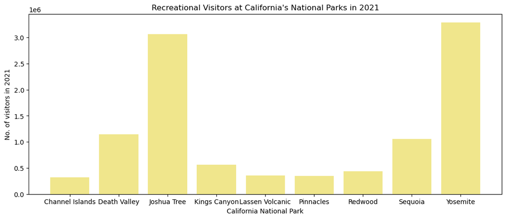

```python
# bar plot of recreation visitors by park
fig = plt.figure(figsize = (13, 5))

plt.bar(df['name_of_park'], df['visitors_in_2021'], color ='khaki',
        width = 0.8)

plt.xlabel("California National Park")
plt.ylabel("No. of visitors in 2021")
plt.title("Recreational Visitors at California's National Parks in 2021")
plt.show()
```

```python
# plot dates established as parks
date = df.sort_values(by='date_established_as_park')



fig = px.scatter(x=df['date_established_as_park'], y=df['name_of_park'], labels={"x": "Year", "y": "Park"}, title='Dates Established as US National Parks in the State of California',)
fig.show()
```

[interactive chart not shown]

```python
fig = px.scatter(df, x=df['date_established_as_park'], y=df['visitors_in_2021'], color=df['name_of_park'], symbol=df['name_of_park'], title='Year of Establishment and Number of Visitors in 2021', labels={"df['date_established_as_park']": "Date Established as Park", "y": "Number of Visitors in 2021"},)
fig.update_traces(marker_size=10)
fig.show()
```

[interactive chart not shown]

**Fun Fact:**

Joshua Tree National Park in California had 3,064,400 visitors in 2021. This was second to only Yosemite, which was established as a park in 1890, over 100 years earlier. Joshua Tree's popularity may have something to do with its driving distance and accessability from major cities such as Los Angeles and San Diego.

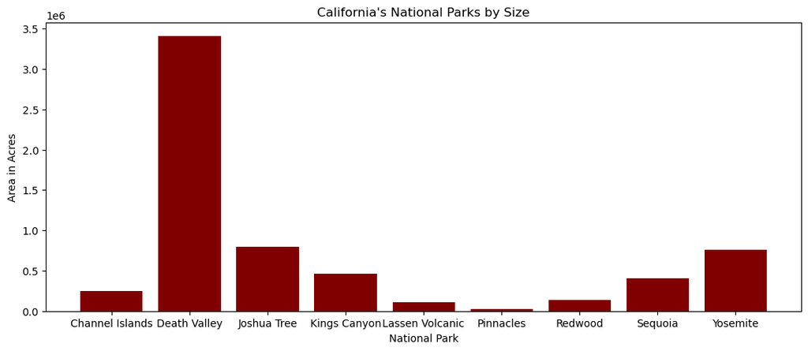

```python
# bar plot of area of parks
fig = plt.figure(figsize = (13, 5))

plt.bar(df['name_of_park'], df['area_in_acres'], color ='maroon',
        width = 0.8)

plt.xlabel("National Park")
plt.ylabel("Area in Acres")
plt.title("California's National Parks by Size")
plt.show()
```

```python
#correlation between visitors in 2021 and area in acres
corr = df['visitors_in_2021'].corr(df['area_in_acres'])

print('The correlation between the area of the parks in acres and the number of visitors is:', corr)
```

```
The correlation between the area of the parks in acres and the number of visitors is: 0.22832525356723213
```

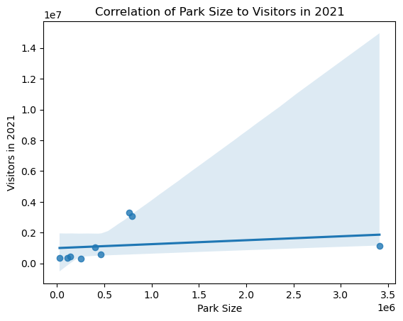

```python
sns.regplot(data=df, x="area_in_acres", y="visitors_in_2021")
plt.title('Correlation of Park Size to Visitors in 2021')
plt.xlabel('Park Size')
plt.ylabel('Visitors in 2021')
plt.show()
```

The seemingly low (0.228) correlation coefficient sugguests little to no relationship between the two columns.

```python
df
```

|  | name_of_park | date_established_as_park | area_in_acres | visitors_in_2021 | description | lat | lon | state |
| --- | --- | --- | --- | --- | --- | --- | --- | --- |
| 11 | Channel Islands | 1980-03-05 | 249561.00 | 319252 | Five of the eight Channel Islands are protecte... | 34.016667 | -119.416667 | California |
| 15 | Death Valley | 1994-10-31 | 3408395.63 | 1146551 | Death Valley is the hottest, lowest, and dries... | 36.233333 | -116.816667 | California, Nevada |
| 34 | Joshua Tree | 1994-10-31 | 795155.85 | 3064400 | Covering large areas of the Colorado and Mojav... | 33.783333 | -115.900000 | California |
| 37 | Kings Canyon | 1940-03-04 | 461901.20 | 562918 | Home to several giant sequoia groves and the G... | 36.800000 | -118.550000 | California |
| 40 | Lassen Volcanic | 1916-08-09 | 106589.02 | 359635 | Lassen Peak, the largest lava dome volcano in ... | 40.483333 | -121.516667 | California |
| 48 | Pinnacles | 2013-01-10 | 26685.73 | 348857 | Named for the eroded leftovers of a portion of... | 36.483333 | -121.166667 | California |
| 49 | Redwood | 1968-10-02 | 138999.37 | 435879 | This park and the co-managed state parks prote... | 41.300000 | -124.000000 | California |
| 52 | Sequoia | 1890-09-25 | 404062.63 | 1059548 | This park protects the Giant Forest, which boa... | 36.433333 | -118.683333 | California |
| 61 | Yosemite | 1890-10-01 | 761747.50 | 3287595 | Yosemite features sheer granite cliffs, except... | 37.833333 | -119.500000 | California |

```python
df['text'] = df['name_of_park'] + '<br>Area ' + (df['area_in_acres']).astype(str)+' acres'
limits = [(0,2),(2,5),(5,7),(7,9)]
colors = ["royalblue","crimson","lightseagreen","orange","lightgrey"]
cities = []
scale = 5000

fig = go.Figure()

for i in range(len(limits)):
    lim = limits[i]
    df_sub = df[lim[0]:lim[1]]
    fig.add_trace(go.Scattergeo(
        locationmode = 'USA-states',
        lon = df_sub['lon'],
        lat = df_sub['lat'],
        text = df_sub['text'],
        marker = dict(
            size = df_sub['area_in_acres']/scale,
            color = colors[i],
            line_color='rgb(40,40,40)',
            line_width=0.5,
            sizemode = 'area'
        ),
        name = '{0} - {1}'.format(lim[0],lim[1])))

fig.update_layout(
        title_text = 'California National Park Areas<br>(Click legend to toggle traces)',
        showlegend = True,
        geo = dict(
            scope = 'usa',
            landcolor = 'rgb(217, 217, 217)',
        )
    )

fig.show()
```

[interactive chart not shown]

```python
df.set_index('name_of_park',inplace=True)
```

```python
sites = df.loc[:,['lat','lon']]
sites
```

| name_of_park | lat | lon |
| --- | --- | --- |
| Channel Islands | 34.016667 | -119.416667 |
| Death Valley | 36.233333 | -116.816667 |
| Joshua Tree | 33.783333 | -115.900000 |
| Kings Canyon | 36.800000 | -118.550000 |
| Lassen Volcanic | 40.483333 | -121.516667 |
| Pinnacles | 36.483333 | -121.166667 |
| Redwood | 41.300000 | -124.000000 |
| Sequoia | 36.433333 | -118.683333 |
| Yosemite | 37.833333 | -119.500000 |

```python
# function to get distance between points using open source routing
def get_distance(point1: dict, point2: dict) -> tuple:
    """Gets distance between two points en route using http://project-osrm.org/docs/v5.10.0/api/#nearest-service"""

    url = f"""http://router.project-osrm.org/route/v1/driving/{point1["lon"]},{point1["lat"]};{point2["lon"]},{point2["lat"]}?overview=false&alternatives=false"""
    r = requests.get(url)

    # get the distance from the returned values
    route = json.loads(r.content)["routes"][0]
    return (route["distance"])
```

```python
import requests
import json
```

```python
# function to create distance matrix based on distance from open source routing
def compute_distance_matrix(dsites, dist_metric=get_distance):
    """ Creates an N x N distance matrix from a dataframe of N locations
    with a latitute column and a longitude column """
    df_dist_matrix = pd.DataFrame(index=sites.index,
                                  columns=sites.index)

    for orig, orig_loc in sites.iterrows():  # for each origin
        for dest, dest_loc in sites.iterrows():  # for each destination
            df_dist_matrix.at[orig, dest] = get_distance(orig_loc, dest_loc)
    return df_dist_matrix


df_distances = compute_distance_matrix(sites)

display(df_distances)
```

| name_of_park | Channel Islands | Death Valley | Joshua Tree | Kings Canyon | Lassen Volcanic | Pinnacles | Redwood | Sequoia | Yosemite |
| --- | --- | --- | --- | --- | --- | --- | --- | --- | --- |
| Channel Islands | 0 | 498682.3 | 358268.7 | 439515.7 | 896276.7 | 393402.5 | 1090445.6 | 371054.6 | 579655 |
| Death Valley | 498476.5 | 0 | 571796.3 | 637199.1 | 846903 | 669984.5 | 1191139.9 | 568738 | 446748.7 |
| Joshua Tree | 361101.1 | 570260.3 | 0 | 672882.5 | 1129643.4 | 689940.8 | 1408445.6 | 604421.4 | 722871.4 |
| Kings Canyon | 439411.8 | 637869.8 | 669904.6 | 0 | 677296.3 | 380772.8 | 956098.5 | 180047.8 | 350752.9 |
| Lassen Volcanic | 896165.3 | 857908.1 | 1126658.2 | 677830.7 | 0 | 564056.9 | 390421.1 | 679712.8 | 528779.4 |
| Pinnacles | 393380.4 | 670252.7 | 686432.2 | 380905.9 | 563178.1 | 0 | 709139.7 | 302240.4 | 359043.5 |
| Redwood | 1090903.7 | 1201219.4 | 1361859.8 | 954949.3 | 389495.6 | 709848.3 | 0 | 956831.4 | 817947.8 |
| Sequoia | 370857.4 | 569315.3 | 601350.2 | 179888.9 | 679050.3 | 302263.6 | 957852.4 | 0 | 357060.1 |
| Yosemite | 574687.3 | 446762.7 | 723479.8 | 346161.4 | 528635.2 | 358983.6 | 819256.6 | 352728.7 | 0 |

```python
# convert distance matrix to array
distance_matrix = df_distances.values
distance_matrix
```

```
array([[0, 498682.3, 358268.7, 439515.7, 896276.7, 393402.5, 1090445.6,
        371054.6, 579655],
       [498476.5, 0, 571796.3, 637199.1, 846903, 669984.5, 1191139.9,
        568738, 446748.7],
       [361101.1, 570260.3, 0, 672882.5, 1129643.4, 689940.8, 1408445.6,
        604421.4, 722871.4],
       [439411.8, 637869.8, 669904.6, 0, 677296.3, 380772.8, 956098.5,
        180047.8, 350752.9],
       [896165.3, 857908.1, 1126658.2, 677830.7, 0, 564056.9, 390421.1,
        679712.8, 528779.4],
       [393380.4, 670252.7, 686432.2, 380905.9, 563178.1, 0, 709139.7,
        302240.4, 359043.5],
       [1090903.7, 1201219.4, 1361859.8, 954949.3, 389495.6, 709848.3, 0,
        956831.4, 817947.8],
       [370857.4, 569315.3, 601350.2, 179888.9, 679050.3, 302263.6,
        957852.4, 0, 357060.1],
       [574687.3, 446762.7, 723479.8, 346161.4, 528635.2, 358983.6,
        819256.6, 352728.7, 0]], dtype=object)
```

```python
pip install python-tsp
```

[output not shown]

[output not shown]

```python
from python_tsp.exact import solve_tsp_brute_force


order, distance_tot = solve_tsp_brute_force(distance_matrix)
```

```python
order
```

```
[0, 2, 1, 8, 4, 6, 5, 7, 3]
```

```python
distance_tot
```

```
3925723.3999999994
```